# Integrating CITE-seq (ADT) and RNAseq

Søren H Dam

Last updated on 2026-05-18

This vignette demonstrates integrating scRNA-seq and the ADT-part of an unrelated CITE-seq dataset using cyCombine. In order to assimilate the two data modalities, we use our own implementation of a Single-cell nearest-neighbor pseudobulking (scennep).

## Dependencies

```r
# remotes::install_github("mojaveazure/seurat-disk#198")
library("Seurat")
library("SeuratDisk")
library("dplyr")
library("ggplot2")
library("patchwork")
library("cyDefine") # Available at https://github.com/biosurf/cyDefine
library("cyCombine")
library("scennep")

seed <- 942
mc.cores <- 39
rerun <- FALSE
system("mkdir -p data")
system("mkdir -p results")
```

## The datasets

### scRNA-seq

We are using the normal samples from a public COVID paper, [Lee et al., 2020](https://www.science.org/doi/10.1126/sciimmunol.abd1554)

```r
# Individual Single-Cell RNA-seq PBMC Data from Lee et al. (DOI: 10.1126/sciimmunol.abd1554)
if (file.exists("data/01_lee.rds")) {
  rnaseq <- readRDS("data/01_lee.rds")
} else {
  system("wget https://datasets.cellxgene.cziscience.com/bdee03e4-14ee-4f3e-a225-3d12f032841f.rds -O data/lee.rds")

  # Load and transform Lee
  lee <- readRDS("data/lee.rds")
  if (! "SCT" %in% Seurat::Assays(lee)) {
    lee <- lee[, grepl("Normal", lee$sample)]
    lee <- FindVariableFeatures(lee)
    oopts <- options(future.globals.maxSize = 1.0 * 1e9)
    on.exit(options(oopts))

    lee <- Seurat::SCTransform(lee)
    lee <- FindVariableFeatures(lee)

    lee@reductions <- list()
    lee[["RNA"]] <- NULL
  }

  # Align annotation labels
  lee$batch <- "lee"
  lee$sample <- "lee"
  celltype <- lee$Cell.group
  lee$celltype <- dplyr::case_when(
           celltype == "B cell" ~ "B cells",
           stringr::str_starts(celltype, "CD4") ~ "CD4pos",
           stringr::str_starts(celltype, "CD8") ~ "CD8pos",
           stringr::str_ends(celltype, "Monocyte") ~ "Monocytes",
           celltype == "NK cell" ~ "NK cells",
           celltype %in% c("cDC", "pDC") ~ paste0(celltype, "s"),
           lee$cell_type == "gamma-delta T cell" ~ "TCRgd",
           lee$cell_type == "platelet" ~ "Platelets",
           TRUE ~ "Other"
           )
  saveRDS(lee, "data/01_lee.rds")
  system("rm data/lee.rds")

  rnaseq <- lee
  rm(lee)
}
```

### CITE-seq

We use the Seurat PBMC atlas by Hao et al., 2021

```r
if (file.exists("data/01_citeseq_seurat_adt.RDS") & !rerun) {
  adt <- readRDS("data/01_citeseq_seurat_adt.RDS")
} else {
  seu_pbmc <- LoadH5Seurat("/home/projects/dp_immunoth/people/s153398/cytograted/data/aml/scrna-seq/pbmc_multimodal.h5seurat",
                            assays = c("ADT"),
                            reductions = FALSE,
                            graphs = FALSE,
                            images = FALSE)

  seu_pbmc$batch <- seu_pbmc$orig.ident
  seu_pbmc$sample <- "ADT"
  suppressMessages({ # Hide per-cluster correction info
  seu_pbmc <- seu_pbmc |>
    cyCombine(
      norm_method = "clr",
      markers = rownames(seu_pbmc),
      xdim = 4, ydim = 3,
      cluster_method = "kohonen",
      layer = "data",
      mc.cores = 1
    )
  })


  adt <- seu_pbmc |>
    GetAssayData("cyCombine", "data") |>
    t() |>
    tibble::as_tibble() |>
    mutate(
      sample = "ADT",
      batch = "ADT",
      cell_id = colnames(seu_pbmc),
      celltype = seu_pbmc$celltype.l2,
      celltype = dplyr::case_when(
    startsWith(celltype, "B") ~ "B cells",
    endsWith(celltype, "Mono") ~ "Monocytes",
    startsWith(celltype, "CD4") ~ "CD4pos",
    celltype == "Treg" ~ "CD4pos",
    startsWith(celltype, "CD8") ~ "CD8pos",
    startsWith(celltype, "NK") ~ "NK cells",
    celltype == "gdT" ~ "TCRgd",
    celltype == "pDC" ~ "pDCs",
    startsWith(celltype, "cDC") ~ "cDCs",
    celltype == "ASDC" ~ "cDCs",
    celltype == "TCRgd" ~ celltype,
    # celltype == "Platelets" ~ celltype,
    TRUE ~ "Other"
  ))
}
```

### Map CITE-seq markers to gene names

```r
if (!file.exists("data/01_citeseq_seurat_adt.RDS") | rerun) {
  # Download marker info
  if (!file.exists("ab_info.xlsx")) system("wget https://ars.els-cdn.com/content/image/1-s2.0-S0092867421005833-mmc1.xlsx -O ab_info.xlsx")

  # Load marker mapper
  gene_marker <- readxl::read_excel("ab_info.xlsx")

  # gene_marker <-
  gene_marker$`Ensembl Gene Id` <- gene_marker$`Ensembl Gene Id` |> stringr::str_remove_all(".*MUS.* ")
  gene_marker$`#protein` <- gsub("_", "-", gene_marker$`#protein`)
  # Select relevant genes-marker pairs
  gm <- sapply(colnames(adt), function(m) gene_marker$`Ensembl Gene Id`[stringr::str_detect(gene_marker$`#protein`, m)][1])

  # Manually assign gene IDs for remaining markers
  gm[is.na(gm)]
  gm[c("CD11a/CD18", "CD18") ] <- c("ENSG00000005844", "ENSG00000160255")
  gm <- gsub("ENSMUSG\\d+, ", "", gm)
  gm <- gsub("NA", NA, gm)
  # gm[c("Integrin-7", "CD3-1", "CD3-2", "TIM-4", "Notch-1", "Notch-2", "cell", "CD11a/CD18", "CD18") ] <- c("ENSG00000139626", "ENSG00000167286", "ENSG00000198851", "ENSG00000145850", "ENSG00000148400", "ENSG00000074181", NA, "ENSG00000005844", "ENSG00000160255")
  gm <- gm[!is.na(gm)]

  colnames(adt)[which(colnames(adt) %in% names(gm))] <- gm[colnames(adt)[which(colnames(adt) %in% names(gm))]]
  c <- colnames(adt)
  duplicated_genes <- unique(c[duplicated(c) & !is.na(c)])
  duplicated_location <- which(c %in% duplicated_genes)

  dup_pbmc <- lapply(setNames(duplicated_genes, duplicated_genes), function(gene) {
    dup_max <- apply(adt[, gm[gm == gene]], 1, max)
    return(dup_max)
  })
  adt[, duplicated_location] <- NULL

  # colnames(seu_pbmc) <- gm[match(colnames(seu_pbmc), names(gm))]
  # seu_pbmc <- seu_pbmc[, !is.na(colnames(seu_pbmc))]
  adt <- cbind(adt, dup_pbmc)

  # Replace column names
  # colnames(seu_pbmc_df)[duplicated(colnames(seu_pbmc_df))]

  adt <- adt |>
    dplyr::select(dplyr::any_of(non_markers), dplyr::starts_with("ENSG"))

  saveRDS(adt, file = "data/01_citeseq_seurat_adt.RDS")
}
```

## Pseudobulk neighbors of scRNA-seq

```r
# Common markers
markers <- intersect(get_markers(adt), get_markers(rnaseq))

# Pseudobulk rnaseq
rna <- scennep(
  rnaseq,
  mc.cores = mc.cores,
  distance = "cosine",
  markers = markers,
  pb = TRUE,
  return_S4 = FALSE)
```

```
## Using the top 22 pcs for the SNN
```

```
## Building SNN graph with k = 20
```

```
## Pseudobulking each cell with its 20 nearest neighbors
```

## Merge datasets

```r
rnaseq_df <- rna |>
  t() |>
  tibble::as_tibble() |>
  dplyr::mutate(
    batch = "scRNA-seq",
    sample = "scRNA-seq",
    celltype = rnaseq$celltype)

# Merge datasets
set.seed(seed)
uncorrected <- adt |>
  dplyr::slice_sample(n = ncol(rna)*2) |>
  dplyr::select(dplyr::any_of(c(markers, non_markers))) |>
  dplyr::bind_rows(rnaseq_df) |>
  dplyr::mutate(id = dplyr::row_number())

# saveRDS(uncorrected, "results/02_rnaseq_citeseq_uncorrected.RDS")
```

## Uncorrected

```r
set.seed(seed)
uncor_batch <- uncorrected |>
  group_by(sample) |>
  slice_sample(n = 5000) |>
  plot_umap(
  down_sample = F,
  markers = markers,
  metric = "cosine",
  title = "scRNA-seq + CITE-seq (ADT)",
  legend_title = "Technology",
  col = "batch")
```

```
## Generating UMAP
```

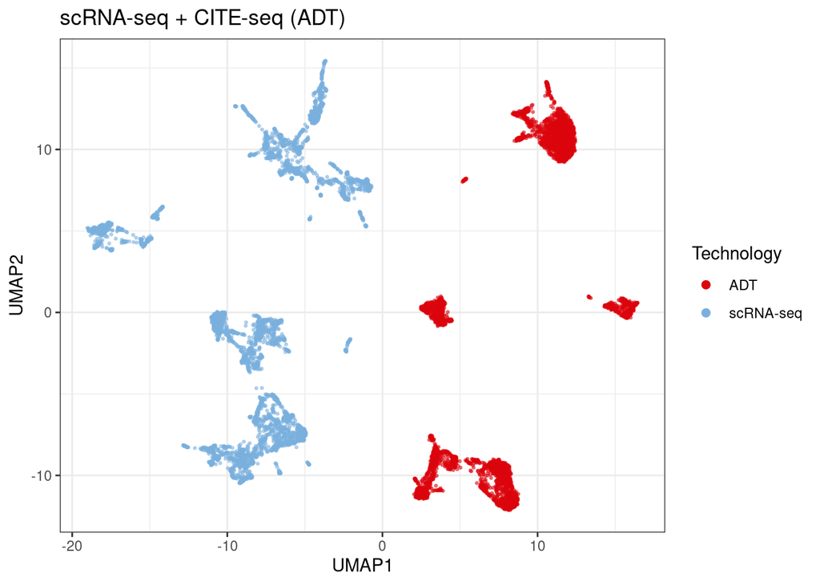

```r
# saveRDS(uncor_batch, "results/02_rnaseq_citeseq_uncor.RDS")
uncor_batch
```

## Integration

For this integration, we are running three iterations of cyCombine to ensure a robust result. The first iteration excludes a clustering step, the second uses a coarse 1x4 grid clustering, and the final iteration uses a somewhat fine-grained 5x5 clustering grid. Cosine distance is used with a FlowSOM clustering to emphasize the angle of variation rather than the amplitude. Note that cosine distance is not available in the default Kohonen cluster method.

```r
system.time({
  suppressMessages({ # Hide per-cluster correction info
  corrected <- cyCombine(
    uncorrected,
    markers = markers,
    cluster_method = "flowsom",
    distf = "cosine",
    seed = seed,
    xdim = c(1,1,5),
    ydim = c(1,4,5),
    mc.cores = 1, pb = F
  )
  })
})
```

[output not shown]

```
##    user  system elapsed
## 141.573  36.170  27.465
```

```r
# saveRDS(corrected, "results/02_rnaseq_citeseq_corrected.RDS")
```

## Plot results - Batch

```r
set.seed(seed)
umap_batch <- corrected |>
  group_by(sample) |>
  slice_sample(n = 5000) |>
  plot_umap(
    return_data = T,
    down_sample = F,
    metric = "cosine",
    markers = markers,
    title = "scRNA-seq + CITE-seq (ADT)",
    legend_title = "Technology",
    col = "batch")
```

```
## Generating UMAP
```

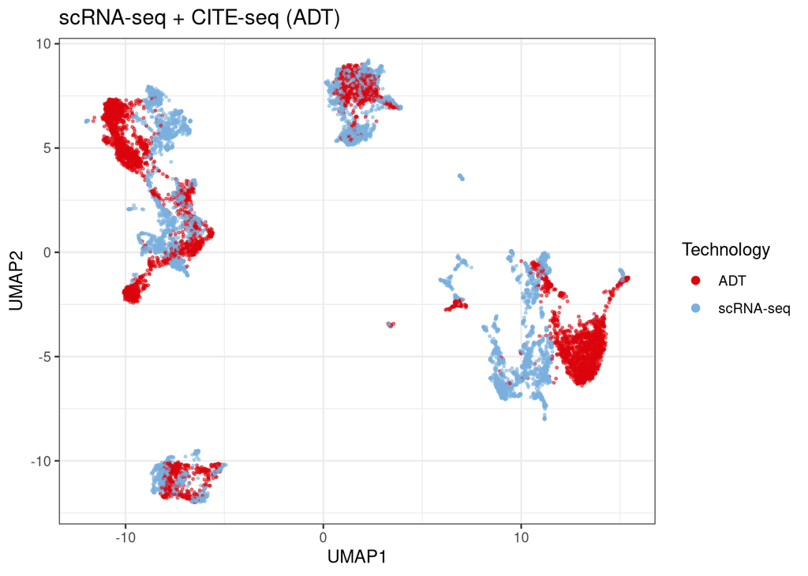

```r
# ggplot2::ggsave(umap_batch$plot, filename = "figs/02_rnaseq_citeseq_batch.png")
# saveRDS(umap_batch$plot, "results/02_rnaseq_citeseq_batch.RDS")
umap_batch$plot
```

## Plot results - Cells

Note: We use `plot_embedding` to reuse the UMAP coordinates from the plot above. We could also have rerun `plot_umap` for a simpler call.

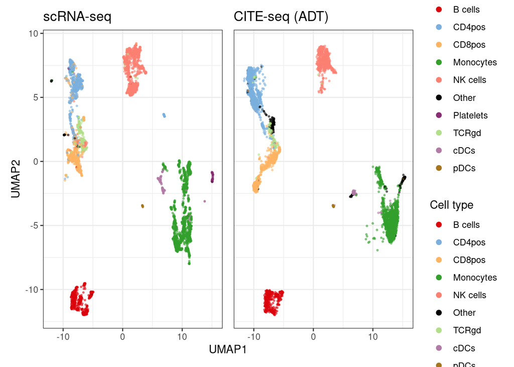

```r
celltype_colors <- cyDefine::get_distinct_colors(sort(unique(uncorrected$celltype)))
celltype_colors[["Other"]] <- "black"

xlim <- c(min(umap_batch$data$UMAP1), max(umap_batch$data$UMAP1))
ylim <- c(min(umap_batch$data$UMAP2), max(umap_batch$data$UMAP2))

plot_cell <-
  plot_embedding(
    dplyr::filter(umap_batch$data, batch == "scRNA-seq"),
    colors = celltype_colors,
    xlim = xlim,
    ylim = ylim,
    title = "scRNA-seq",
    col = "celltype",
    legend_title = "Cell type") +
  plot_embedding(
    dplyr::filter(umap_batch$data, batch == "ADT"),
    colors = celltype_colors,
    xlim = xlim,
    ylim = ylim,
    title = "CITE-seq (ADT)",
    col = "celltype",
    legend_title = "Cell type") +
  patchwork::plot_layout(
    guides = "collect",
    axes = "collect",
    axis_titles = "collect")


# saveRDS(plot_cell, "results/02_rnaseq_citeseq_cell.RDS")
# ggplot2::ggsave(plot_cell, filename = "figs/02_rnaseq_citeseq_cell.png")
plot_cell
```

## Measure performance

- EMD: Reduction in Earth Movers Distance [0,1] is a metric of how much more aligned the two modalities have become
- MAD: Reduction in Median Absolute Deviation [0,1] is a metric of how much biological variance has been removed.
- CiLISI: Cell-type aware iLISI [0,1] is the global mean of the iLISIs computed for each cell type or cluster.

```r
corrected$label <- create_som(corrected, ydim = 5, xdim = 5, seed = seed, markers = markers, cluster_method = "flowsom", distf = "cosine")
```

```
## Building SOM
```

```
## Mapping data to SOM
```

```r
uncorrected$label <- corrected$label

system.time({
  lu <- cyCombine::compute_cilisi(df = uncorrected, markers = get_markers(uncorrected), label_cols = "batch", split_by = "label", return_mean = F)
})
```

```
##    user  system elapsed
##   1.387   0.041   1.431
```

```r
message("CiLISI uncorrected: ", mean(unlist(lu)))
```

```
## CiLISI uncorrected: 0.0100336224311687
```

```r
system.time({
  l <- cyCombine::compute_cilisi(df = corrected, markers = get_markers(corrected), label_cols = "batch", split_by = "label", return_mean = F)
})
```

```
##    user  system elapsed
##   1.562   0.024   1.590
```

```r
message("CiLISI corrected: ", mean(unlist(l)))
```

```
## CiLISI corrected: 0.205777538046448
```

```r
mad <- cyCombine::evaluate_mad(uncorrected, corrected, cell_col = "label", markers = markers)
```

```
## Computing MAD for corrected data..
```

```
## Computing MAD for uncorrected data..
```

```
## The MAD score is: 0.03
```

```r
emd <- cyCombine::evaluate_emd(uncorrected, corrected, cell_col = "label", markers = markers)
```

```
## Computing EMD for corrected data..
```

```
## Binning destributions using binSize 0.1
```

```
## Computing marker-wise EMD for each cell cluster
```

```
## Computing EMD for uncorrected data..
```

```
## Binning destributions using binSize 0.1
```

```
## Computing marker-wise EMD for each cell cluster
```

```
## Removing EMDs below 2 both before and after correction
```

```
## The reduction is: 0.8
```

```
## Creating plots..
```

```
## Evaluation complete.
```

```r
# saveRDS(list("emd" = emd, "mad" = mad, "CiLISI_uc" = lu, "CiLISI_c" = l), "results/02_rnaseq_citeseq_performance.RDS")
```

Contact